# Live Session 6 HW

Audrene Tiakor

February 15, 2019

```r
library(dplyr)
```

```r
library(ggplot2)
```

## Question 1: Mental Health (40 pts):

### a. download rda file from https://datafiles.samhsa.gov/study-dataset/national-mental-health-services-survey-2015-n-mhss-2015-ds0001-nid17098

```r
setwd("C:\\Users\\Audrene\\Desktop\\SMU_MSDS_PROGRAM\\Term1_spring2019\\MSDS6306\\HW\\live_session_6")
mental.sur<-load(file="N-MHSS-2015-DS0001-data-r.rda")
mental.sur
```

```
## [1] "mh2015_puf"
```

```r
survey<-mh2015_puf
```

### b.create code tht lists the State abbreviations without their counts

```r
states<-levels(survey$LST)
levels(survey$LST) <- gsub(" ","",levels(survey$LST))
print (paste("All State Abbreviations: ", paste(unique(survey$LST), collapse = " ")))
```

```
## [1] "All State Abbreviations:  AL AK AZ AR CA CO CT DE DC FL GA HI ID IL IN IA KS KY LA ME MD MA MI MN MS MO MT NE NV NH NJ NM NY NC ND OH OK OR PA RI SC SD TN TX UT VT VA WA WV WI WY AS GU PR VI"
```

### c. Filter the data frame from 1A, creat a list of counts for the VA medical centers in the mainland United States, ommit Alaska, Hawaii, and U.S. territories, convert this result to a data frame

```r
facility<-levels(survey$FACILITYTYPE)
facility_byState <- survey %>% filter(survey$FACILITYTYPE == "Veterans Administration medical center (VAMC) or other VA health care facility") %>% count(LST)
drops <- c('AK', 'HI', 'PR', 'AS', 'FM', 'GU', 'MH', 'MP', 'PW', 'PR', 'VI')
va_centers <- data.frame(facility_byState[!(facility_byState$LST %in% drops), ])
names(va_centers)<-c("State", "Counts")
names(va_centers)
```

```
## [1] "State"  "Counts"
```

*Note: The original names of va_centers were ‘LST’ and ‘n’. To make this dataframe more human readable, the names were changed to “State” and “Counts”.

### d. Create a ggplot of the filtered data set ‘va_centers’, vary the bar’s colors by State, give an appropriate professional title that is centered, make sure axes are have informative titles, State axis should be readable, and not layered over each other, legend is included

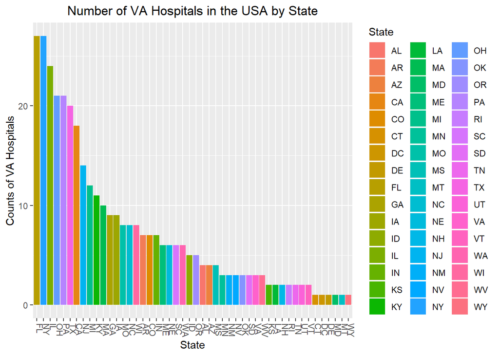

```r
ggplot(va_centers,aes(x=State,y=Counts,fill=State)) +
geom_bar(aes(reorder(State,-Counts)), stat="identity") +
theme(axis.text.x = element_text(angle = -90, hjust = 0, vjust = 0), legend.position = "right") + ggtitle("Number of VA Hospitals in the USA by State") + xlab("State") + ylab("Counts of VA Hospitals") + theme(plot.title= element_text(hjust = 0.5))
```

## Question 2: Mental Health (40 pts): ###a. Import Statesize.csv data into R/ merge statsize dataset with dataset from question 1

```r
state <- read.csv("statesize.csv")
str(state)
```

```
## 'data.frame':    50 obs. of  4 variables:
##  $ StateName: Factor w/ 50 levels "Alabama","Alaska",..: 1 2 3 4 5 6 7 8 9 10 ...
##  $ SqMiles  : int  50750 570374 113642 52075 155973 103730 4845 1955 53997 57919 ...
##  $ Abbrev   : Factor w/ 50 levels "AK","AL","AR",..: 2 1 4 3 5 6 7 8 9 10 ...
##  $ Region   : Factor w/ 4 levels "Midwest","Northeast",..: 3 4 4 3 4 4 2 3 3 3 ...
```

```r
state.va <- merge(va_centers,state, by.x = 'State', by.y = 'Abbrev', all.x = TRUE)
str(state.va)
```

```
## 'data.frame':    48 obs. of  5 variables:
##  $ State    : Factor w/ 55 levels "AK","AL","AR",..: 2 3 5 6 7 8 9 10 11 12 ...
##  $ Counts   : int  4 7 4 18 7 1 1 1 27 9 ...
##  $ StateName: Factor w/ 50 levels "Alabama","Alaska",..: 1 4 3 5 6 7 NA 8 9 10 ...
##  $ SqMiles  : int  50750 52075 113642 155973 103730 4845 NA 1955 53997 57919 ...
##  $ Region   : Factor w/ 4 levels "Midwest","Northeast",..: 3 3 4 4 4 2 NA 3 3 3 ...
```

```r
anyNA(state.va)
```

```
## [1] TRUE
```

```r
state.va[rowSums(is.na(state.va)) > 0,]
```

```
##   State Counts StateName SqMiles Region
## 7    DC      1      <NA>      NA   <NA>
```

### c. calculate a new variable in your combined dataframe, which indicates the VA hopsitals per thousand square miles

```r
state.va$num.per.1000.sq.miles <- state.va$Count / state.va$SqMiles * 1000
```

### d. Create another ggplot

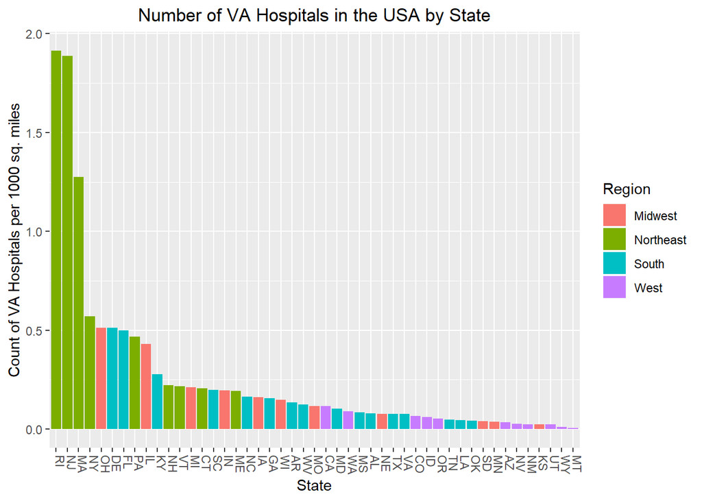

```r
ggplot(na.omit(state.va),aes(x=State,y=num.per.1000.sq.miles,fill=Region)) +
  geom_bar(aes(reorder(State,-num.per.1000.sq.miles)), stat="identity")  +
  theme(axis.text.x = element_text(angle = -90, hjust = 0, vjust = 0)) +
  ggtitle("Number of VA Hospitals in the USA by State") + xlab("State") + ylab("Count of VA Hospitals per 1000 sq. miles") +
  theme(plot.title= element_text(hjust = 0.5))
```

[output not shown]